# COMP60711 - Part 2 Coursework 1

[output not shown]

Please complete the questions in the spaces provided (under the "Answer" block for each question), then download the notebook in HTML format and submit to Blackboard.

Please also add your student ID and name below.

| Student ID (7-8 digit number) | Full Name |
| --- | --- |
| 10868665 | Zirui Wang |

## Reminders

- **Please make clear any assumptions and provide evidence to justify your answers**
- Jupyter notebooks use markdown. A brief summary of how to use markdown can be seen [here](https://github.com/adam-p/markdown-here/wiki/Markdown-Cheatsheet). Otherwise, please refer to the brief guide on Blackboard.
- You **must** cite any sources used, from web pages to academic papers and textbooks.
- Please ensure your code has no errors, and that the output is shown in your submitted version.
- We have added some general notebooks on Blackboard to cover the basics of plotting in Python, Jupyter notebooks, and anaconda.
- Some questions require a mixture of code and text to answer the question. Marks are awarded based on the output of your code (i.e. graphs) and the explanation provided, not on the code itself.

# Question 1: Clustering (16 marks)

The following sub-questions are about [clustering](https://www-users.cs.umn.edu/~kumar001/dmbook/ch8.pdf). In general, the topics covered are as follows:

- Question 1.1 focuses on clustering algorithmic behaviour, and their sensitivity to data.
- Question 1.2 focuses on method for estimating the number of clusters.
- Question 1.3 uses a large real-world dataset to look at how clustering can be used for knowledge discovery.

The following reading is likely to be of use for the following questions:

1. Book chapter on clustering: https://www-users.cs.umn.edu/~kumar001/dmbook/ch8.pdf
   - Note that certain sections may be useful, you are not expected to read it all!
2. Here is an example of running KMeans using scikit-learn: https://scikit-learn.org/stable/auto_examples/cluster/plot_kmeans_assumptions.html

For this question, we will use multiple datasets, which can all be found on Blackboard. To load these datasets in, we can use the following code. Note that you may need to adjust the path to the dataset, depending on where they are located on your system.

```python
import pandas as pd

def load_dataset(file_name, **kwargs):
    try:
        data = pd.read_csv(file_name, **kwargs)
    except FileNotFoundError:
        raise FileNotFoundError(f"Cannot find {file_name}, please either place the file in the same directory as this notebook, or provide the full path")
    labels = data.values[:, -1]
    data = data.values[:, :-1]
    return data, labels

# This loads the dataset used in Q1.1a
simple_data, simple_labels = load_dataset("simple.csv")
```

## Q1.1 (6 marks)

### Q1.1a (2 marks)

Using `simple.csv`, run the K-Means and single-linkage algorithms (available in [`scikit-learn`](https://scikit-learn.org/stable/modules/clustering.html)) on the dataset, using the true number of clusters ($K=5$). Produce a graph (e.g. bar chart) showing the performance (measured using the [adjusted rand index](https://scikit-learn.org/stable/modules/generated/sklearn.metrics.adjusted_rand_score.html)) across 10 independent runs. Discuss the results obtained, using your knowledge of how the algorithms work to explain why the behaviour observed occurred.

**Hints:**

- This question is more difficult without the use of error bars!
- For single-linkage, use `AgglomerativeClustering(n_clusters=5, linkage="single")`
- For KMeans, use `KMeans(n_clusters=5, init="random", n_init=1)` as arguments.

### Q1.1a Answer

```python
# import libraries
import numpy as np
from sklearn.cluster import AgglomerativeClustering, KMeans
from sklearn.metrics import adjusted_rand_score, silhouette_score
import matplotlib.pyplot as plt
from sklearn.preprocessing import MinMaxScaler
import seaborn as sns
from datetime import datetime
```

```python
# Please enter any relevant code for Q1.1a below.
# You can use multiple cells if it helps break up the code execution
kmeans_ari_list = []
singleLinkage_ari_list = []

for i in range(10):
    kmeans = KMeans(n_clusters=5, init="random", n_init=1)
    kmeans_fit = kmeans.fit(simple_data)

    singleLinkage = AgglomerativeClustering(n_clusters=5, linkage="single")
    singleLinkage_fit = singleLinkage.fit(simple_data)

    kmeans_ari_list.append(adjusted_rand_score(simple_labels, kmeans_fit.labels_))
    singleLinkage_ari_list.append(adjusted_rand_score(simple_labels, singleLinkage_fit.labels_))

kmeans_ari_mean = np.mean(kmeans_ari_list)
singleLinkage_ari_mean = np.mean(singleLinkage_ari_list)

kmeans_ari_std = np.std(kmeans_ari_list)
singleLinkage_ari_std = np.std(singleLinkage_ari_list)
```

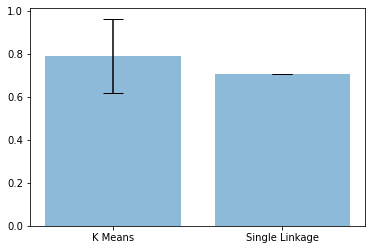

```python
x_strings = ["K Means", "Single Linkage"]
y_height = [kmeans_ari_mean, singleLinkage_ari_mean]
error = [kmeans_ari_std, singleLinkage_ari_std]

plt.bar(x=x_strings, height=y_height, yerr=error, align="center", ecolor="black", capsize=10, alpha=0.5)
plt.show()
```

#### Q1.1a Analysis

As can be seen from the above figure, the average adjusted Rand score of kmeans is about 0.8. Through multiple runs, it can be found that this score will be different, fluctuating between 0.6 and 0.9. The adjusted Rand Score of linkage algorithm is 0.7 every time, and there is no fluctuation. Combined with error bar, i.e. standard deviation, K-Means is in low stability, because this algorithm clustered by initialized points randomly and the clustering result depends on the position of the initial points.

For better explanation, visualize the data and the center points obtained by K-Means clustering (both correct and wrong center points).

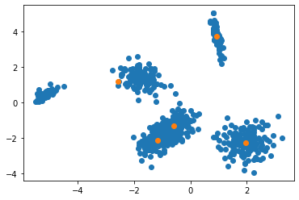

```python
centers = KMeans(n_clusters=5, init="random", n_init=1).fit(simple_data).cluster_centers_

plt.scatter(simple_data[:,0], simple_data[:,1])
plt.scatter(centers[:,0], centers[:,1])
plt.show()
```

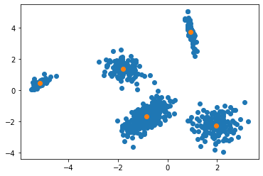

```python
centers = KMeans(n_clusters=5, init="random", n_init=1).fit(simple_data).cluster_centers_

plt.scatter(simple_data[:,0], simple_data[:,1])
plt.scatter(centers[:,0], centers[:,1])
plt.show()
```

The data in this dataset exist in spheres or bars, and there are intervals between each cluster.

K-Means is an algorithm based on centroid clustering. As mentioned above, the initial centroids are random, and there will be cases where two clusters share one centroid, or one cluster has two centroids. In this case, the ARI of K-Means is low. In another case, the centroids is correct initially, and then the cluster result is correct, which makes the API high. Therefore, the performance of K-Means is unstable (n_init=1 means it runs only once).

Single-Linkage algorithm is to treat each point as a cluster, and then merge the two nearest clusters. Three clusters in this dataset are spaced closely, so incorrect clustering may occur, and the API is low. However, the distances of each cluster does not change with each run, and the final clustering results are the same, which makes the Single-Linkage algorithm very stable.

### Q1.1b (2 marks)

Using the dataset named `q1-1b.csv`, perform the same experiment as in Q1.1a. Discuss the ARI results obtained, particularly how and why the results are different from Q1.1a.

**Hint:**

- Visualizing the data itself may help to support your discussion.

### Q1.1b Answer

```python
data, labels = load_dataset("q1-1b.csv")

kmeans_ari_list = []
singleLinkage_ari_list = []

for i in range(10):
    kmeans = KMeans(n_clusters=5, init="random", n_init=1)
    kmeans_fit = kmeans.fit(data)

    singleLinkage = AgglomerativeClustering(n_clusters=5, linkage="single")
    singleLinkage_fit = singleLinkage.fit(data)

    kmeans_ari_list.append(adjusted_rand_score(labels, kmeans_fit.labels_))
    singleLinkage_ari_list.append(adjusted_rand_score(labels, singleLinkage_fit.labels_))

kmeans_ari_mean = np.mean(kmeans_ari_list)
singleLinkage_ari_mean = np.mean(singleLinkage_ari_list)

kmeans_ari_std = np.std(kmeans_ari_list)
singleLinkage_ari_std = np.std(singleLinkage_ari_list)
```

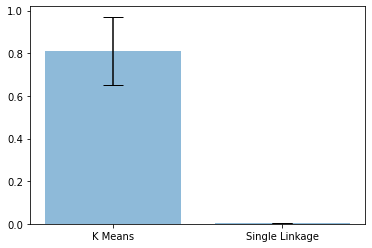

```python
x_strings = ["K Means", "Single Linkage"]
y_height = [kmeans_ari_mean, singleLinkage_ari_mean]
error = [kmeans_ari_std, singleLinkage_ari_std]

plt.bar(x=x_strings, height=y_height, yerr=error, align="center", ecolor="black", capsize=10, alpha=0.5)
plt.show()
```

#### Q1.1b Analysis

As can be seen from the above figure, the average adjusted Rand score of kmeans is about 0.8. Through multiple runs, it can be found that this score will be different, fluctuating between 0.7 and 0.9. The adjusted Rand Score of linkage algorithm is 0 every time, and there is no fluctuation.

For better explanation, visualize the data and the center points obtained by K-Means clustering (both correct and wrong center points).

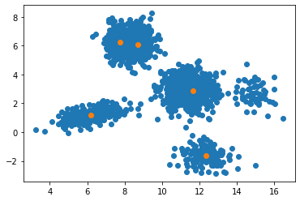

```python
centers = KMeans(n_clusters=5, init="random", n_init=1).fit(data).cluster_centers_

plt.scatter(data[:,0], data[:,1])
plt.scatter(centers[:,0], centers[:,1])
plt.show()
```

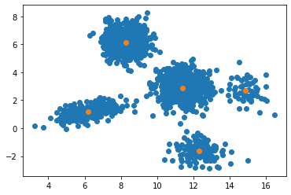

```python
centers = KMeans(n_clusters=5, init="random", n_init=1).fit(data).cluster_centers_

plt.scatter(data[:,0], data[:,1])
plt.scatter(centers[:,0], centers[:,1])
plt.show()
```

For K-Means, different initialization points still correspond to different clustering results. There is still a case that one cluster corresponds to two centroids or two clusters correspond to one centroid. The API score near 0.8 is almost the same as q1.1a.

However, for the Single-Linkage algorithm, the API drops to around 0, which means that almost most clusters are wrong. As can be seen from the above figure, there are two groups of data that are scattered internally, and the distance between each group of data is very close. Single-Linkage may recognize them as one cluster, so wrong clustering occurs

### Q1.1c (2 marks)

Using the dataset named `q1-1c.csv`, perform the same experiment as in Q1.1b. Discuss the results obtained, particularly how and why the results are different from Q1.1b.

**Hints:**

- Visualizing the data itself may help to support your discussion.

### Q1.1c Answer

```python
# Please enter any relevant code for Q1.1c below.
# You can use multiple cells if it helps
data, labels = load_dataset("q1-1c.csv")

kmeans_ari_list = []
singleLinkage_ari_list = []

for i in range(10):
    kmeans = KMeans(n_clusters=5, init="random", n_init=1)
    kmeans_fit = kmeans.fit(data)

    singleLinkage = AgglomerativeClustering(n_clusters=5, linkage="single")
    singleLinkage_fit = singleLinkage.fit(data)

    kmeans_ari_list.append(adjusted_rand_score(labels, kmeans_fit.labels_))
    singleLinkage_ari_list.append(adjusted_rand_score(labels, singleLinkage_fit.labels_))

kmeans_ari_mean = np.mean(kmeans_ari_list)
singleLinkage_ari_mean = np.mean(singleLinkage_ari_list)

kmeans_ari_std = np.std(kmeans_ari_list)
singleLinkage_ari_std = np.std(singleLinkage_ari_list)
```

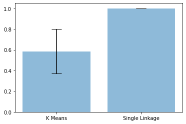

```python
x_strings = ["K Means", "Single Linkage"]
y_height = [kmeans_ari_mean, singleLinkage_ari_mean]
error = [kmeans_ari_std, singleLinkage_ari_std]

plt.bar(x=x_strings, height=y_height, yerr=error, align="center", ecolor="black", capsize=10, alpha=0.5)
plt.show()
```

#### Q1.1c Analysis

As can be seen from the above figure, the average adjusted Rand score of kmeans is about 0.6. Through multiple runs, it can be found that this score will be different, fluctuating between 0.4 and 0.8. The Adjusted Rand Score of linkage algorithm 1.0 every time, and there is no fluctuation.

For better explanation, visualize the data and the center points obtained by K-Means clustering (both are wrong center points).

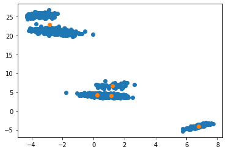

```python
centers = KMeans(n_clusters=5, init="random", n_init=1).fit(data).cluster_centers_

plt.scatter(data[:,0], data[:,1])
plt.scatter(centers[:,0], centers[:,1])
plt.show()
```

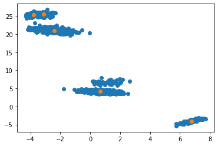

```python
centers = KMeans(n_clusters=5, init="random", n_init=1).fit(data).cluster_centers_

plt.scatter(data[:,0], data[:,1])
plt.scatter(centers[:,0], centers[:,1])
plt.show()
```

The K-Means clustering of this dataset become worse, with only an API of 0.6 on average. It can be seen from the above visualization that the data at this time is a long strip rather than a circle. The distance between the two sets of data is small, the boundary distance of a group of data is farther than the distance between the two groups of data. This makes K-Means unable to find the correct cluster.

Single-Linkage algorithm performs very well. Because the data of the same category are very compact, and there is an obvious boundary between different data groups (although the boundary distance may not be too large, it is enough for Single-Linkage to distinguish two groups of data).

Reference for question 1.1

Kazarinoff, P., 2021. *Bar Charts With Error Bars using Python and Matplotlib.* [online] Python for Undergraduate Engineers. Available at: https://pythonforundergradengineers.com/python-matplotlib-error-bars.html [Accessed 22 October 2021].

## Q1.2 (5 marks)

### Q1.2a (3 marks)

Discuss **two** methods that can be used to estimate the *true* number of clusters. A discussion of the suitability and potential issues with each method is expected. No marks are given beyond the first two methods.

### Q1.2a Answer

```python
# Please enter any relevant code for Q1.2a below
# You can use multiple cells if it helps
```

First is Elbow Method:

The function is: $D_k = \sum_{i=1}^{all \ clusters}{\sum_{j=1}^{all \ points \ in \ that \ cluster} {dist(c_i,x_j)^2}}$

where $c_i$ is the point of cluster center of $i^{th}$ cluster, ${x_j}$ is the $j^{th}$ point in that cluster ($j^{th}$ is for all points in that cluster)

By comparing the D value of the different clusters numbers, choose the "elbow" point as the best cluster number. ("elbow" point: For discriminative data, the d value will be greatly improved when a certain critical point is reached, and then slowly decrease, this critical point can be considered as a point with better clustering performance)

**Suitability:** The discriminative data that have "elbow" point

**Potential issues:** Some data may don't have "elbow" point. If the d values are not vary too much or keep decrease, then this method is not suitable for the data.

Second is Silhouette Method:

The function is: $s_i = \frac {(b_i - a_i)} { max(a_i, b_i)}$

where $a_i$ is the mean value of the distance between $i^{th}$ sample and each other in the cluster, $b_i$ is the mean value from the $i^{th}$ sample to the nearest other cluster samples.

$s_i$ is in range $[-1,1]$, for a clustering task, the samples should be as close as possible within the cluster and as far away from each other as possible. If $s_i$ is close to 1, sample i clustering is reasonable; If $s_i$ is close to - 1, sample i should be classified into another cluster; If $s_i$ is approximately 0, it means that sample i is on the boundary of two clusters.

**Suitability:** not a large dataset

**Potential issues:** This method is computationally expensive and time complexity is very high. Because it evaluate every point in dataset. It is not a good choice for large data sets.

### Q1.2b (2 marks)

Using the `simple.csv` dataset, apply one of the two methods discussed in Q1.2a to estimate the true number of clusters. Was the estimate correct? Discuss your result.

### Q1.2b Answer

**Elbow Method** is used for this question

Assumeing that the cluster number K is unknown, so first a range from 1 to 100 is used to check the "elbow" point. To be more precisely, n_init=10 is used.

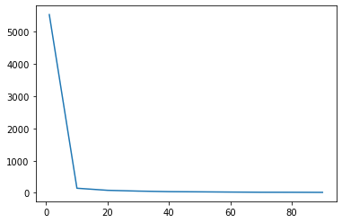

```python
# Please enter any relevant code for Q1.2b below
# You can use multiple cells if it helps
simple_data, simple_labels = load_dataset("simple.csv")

sum_distance_list = []
for i in ([1] + [j for j in range(10,100,10)]):
    kmeans = KMeans(n_clusters=i, init="random", n_init=10)
    kmeans_fit = kmeans.fit(simple_data)
    sum_distance_list.append(kmeans_fit.inertia_)

plt.plot(([1] + [j for j in range(10,100,10)]), sum_distance_list)
plt.show()
```

From above figure, it shows that "elbow" point in 0 to 10. Now check the range from 0 to 10

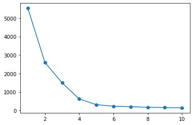

```python
sum_distance_list = []
for i in range(1,11):
    kmeans = KMeans(n_clusters=i, init="random", n_init=10)
    kmeans_fit = kmeans.fit(simple_data)
    sum_distance_list.append(kmeans_fit.inertia_)

plt.plot(range(1,11), sum_distance_list, "o-")
plt.show()
```

Untill now, it's hard to decide which number is K. 4 and 5 both seems like "elbow" point. By definition, there is a high probability that 4 will be selected as the "elbow" point.

Here is used the second method - Silhouette Method to further determine the K value.

```python
kmeans = KMeans(n_clusters=4, init="random", n_init=10).fit(simple_data)
silhouette_score_4 = silhouette_score(simple_data, kmeans.labels_)

kmeans = KMeans(n_clusters=5, init="random", n_init=10).fit(simple_data)
silhouette_score_5 = silhouette_score(simple_data, kmeans.labels_)

kmeans = KMeans(n_clusters=6, init="random", n_init=10).fit(simple_data)
silhouette_score_6 = silhouette_score(simple_data, kmeans.labels_)

print("K=4 slihouette score: ", silhouette_score_4)
print("K=5 slihouette score: ", silhouette_score_5)
print("K=6 slihouette score: ", silhouette_score_6)
```

```
K=4 slihouette score:  0.6906886240290357
K=5 slihouette score:  0.7325759710267562
K=6 slihouette score:  0.6004950508372273
```

Now K=5 is the best number of clusters as it has the highest slihouette score.

In conclusion, for this question, there is an "elbow" point in the dataset, but the elbow method cannot determine the specific K value, and it is easy to select the wrong "elbow" point as 4. However, in combination with the silhouette method, the K value can be finally determined. The advantage is that it avoids the computational complexity of the silhouette method and can find the specific K value in a small range.

Reference list for question 1.2

Bonaros, B. (2019). *K-Means Elbow Method code for Python.* [online] Predictive Hacks. Available at: https://predictivehacks.com/k-means-elbow-method-code-for-python/ [Accessed 22 Oct. 2021].

Wikipedia Contributors (2019a). *Elbow method (clustering).* [online] Wikipedia. Available at: https://en.wikipedia.org/wiki/Elbow_method_(clustering) [Accessed 22 Oct. 2021].

Wikipedia Contributors (2019b). *Silhouette (clustering).* [online] Wikipedia. Available at: https://en.wikipedia.org/wiki/Silhouette_(clustering) [Accessed 22 Oct. 2021].

## Q1.3 (5 marks)

For this question, we will use the `online_retail_full.csv` dataset, which is a real-world dataset of transactions for an online retail store. Full information about the dataset can be found [here](https://archive.ics.uci.edu/ml/datasets/Online+Retail+II). Here, we do not have true labels, and need to explore the data instead. This is a common scenario in practice, and will require you explore the data and use clustering (likely requiring multiple iterations and tweaks) to try to find patterns.

We're going to investigate whether there are groups of customers, how they are similar, and what they may represent. For simplicity, we will start by using KMeans as our model, and we'll remove some of the columns from our input data. Use a range of $K$ values and whichever techniques in Q1.2 are useful to propose interesting $K$ value(s). Comment on the clusters that are produced in terms of the context of the data.

Hints:

- As this dataset has no truth, there is a lot of scope in this question - remember to have some justification for why you have taken the steps you have.
- The quality of your final clusters is not important for marks, as long as you have taken reasonable steps.
- The overall aim is to try to find patterns in the data. KMeans is suggested as a starting point, but it is not always the best algorithm to use as we have seen in previous questions.
- You can create features from the existing ones. For example, the quantity and price can be multiplied to get a total amount (thus simplifying the data). Other features may require transformation before they can be used.

## Q1.3 Answer

First show the shape and info of the data

```python
# Load the data (the path may be different for you, adjust if needed)
retail = pd.read_csv("online_retail_full.csv", index_col=False)
retail.shape
```

```
(1067371, 8)
```

```python
retail.info()
```

```
<class 'pandas.core.frame.DataFrame'>
RangeIndex: 1067371 entries, 0 to 1067370
Data columns (total 8 columns):
 #   Column       Non-Null Count    Dtype
---  ------       --------------    -----
 0   Invoice      1067371 non-null  object
 1   StockCode    1067371 non-null  object
 2   Description  1062989 non-null  object
 3   Quantity     1067371 non-null  int64
 4   InvoiceDate  1067371 non-null  object
 5   Price        1067371 non-null  float64
 6   Customer ID  824364 non-null   float64
 7   Country      1067371 non-null  object
dtypes: float64(2), int64(1), object(5)
memory usage: 65.1+ MB
```

From the output above, we know there are 1,067,371 rows and 8 columns. However, the info() function shows [Column2:Description] and [Column6:Customer ID] have 1,062,989 and 824,364 rows respectively. It can be infered that these two attributes have empty cells. The rows with empty values is simply deleted. Meanwhile, in order to facilitate the further operations, the [InvoiceDate] column is converted to datetime type. Create a new column [Total Price] with the value of [Quantity] * [Price].

```python
retail = retail.dropna()
retail["InvoiceDate"] = pd.to_datetime(retail["InvoiceDate"])
retail["Total Price"] = retail["Quantity"] * retail["Price"]
retail.info()
print("\n The shape after drop empty values", retail.shape)
```

```
<class 'pandas.core.frame.DataFrame'>
Int64Index: 824364 entries, 0 to 1067370
Data columns (total 9 columns):
 #   Column       Non-Null Count   Dtype
---  ------       --------------   -----
 0   Invoice      824364 non-null  object
 1   StockCode    824364 non-null  object
 2   Description  824364 non-null  object
 3   Quantity     824364 non-null  int64
 4   InvoiceDate  824364 non-null  datetime64[ns]
 5   Price        824364 non-null  float64
 6   Customer ID  824364 non-null  float64
 7   Country      824364 non-null  object
 8   Total Price  824364 non-null  float64
dtypes: datetime64[ns](1), float64(3), int64(1), object(4)
memory usage: 62.9+ MB

 The shape after drop empty values (824364, 9)
```

Now, rows with empty values are deleted. Now we have 824,364 rows.

Show first 5 rows of dataset

```python
retail.head()
```

|  | Invoice | StockCode | Description | Quantity | InvoiceDate | Price | Customer ID | Country | Total Price |
| --- | --- | --- | --- | --- | --- | --- | --- | --- | --- |
| 0 | 489434 | 85048 | 15CM CHRISTMAS GLASS BALL 20 LIGHTS | 12 | 2009-12-01 07:45:00 | 6.95 | 13085.0 | United Kingdom | 83.4 |
| 1 | 489434 | 79323P | PINK CHERRY LIGHTS | 12 | 2009-12-01 07:45:00 | 6.75 | 13085.0 | United Kingdom | 81.0 |
| 2 | 489434 | 79323W | WHITE CHERRY LIGHTS | 12 | 2009-12-01 07:45:00 | 6.75 | 13085.0 | United Kingdom | 81.0 |
| 3 | 489434 | 22041 | RECORD FRAME 7" SINGLE SIZE | 48 | 2009-12-01 07:45:00 | 2.10 | 13085.0 | United Kingdom | 100.8 |
| 4 | 489434 | 21232 | STRAWBERRY CERAMIC TRINKET BOX | 24 | 2009-12-01 07:45:00 | 1.25 | 13085.0 | United Kingdom | 30.0 |

Show number of transactions by country

```python
retail["Country"].value_counts()
```

```
United Kingdom          741301
Germany                  17624
EIRE                     16195
France                   14202
Netherlands               5140
Spain                     3811
Belgium                   3123
Switzerland               3064
Portugal                  2504
Australia                 1913
Channel Islands           1664
Italy                     1534
Norway                    1455
Sweden                    1345
Cyprus                    1176
Finland                   1049
Austria                    938
Denmark                    817
Greece                     663
Japan                      582
Poland                     535
USA                        535
Unspecified                524
United Arab Emirates       386
Singapore                  346
Israel                     324
Malta                      299
Iceland                    253
Canada                     228
Lithuania                  189
RSA                        123
Brazil                      94
Thailand                    76
Korea                       63
European Community          61
Bahrain                     59
West Indies                 54
Lebanon                     45
Czech Republic              30
Nigeria                     30
Saudi Arabia                10
Name: Country, dtype: int64
```

From the output above, there is a country valued "Unspecified". This should also be a missing value. Below shows the number of customer whose country is "Unspecified".

```python
retail[retail["Country"]=="Unspecified"].groupby("Customer ID").sum()
```

| Customer ID | Quantity | Price | Total Price |
| --- | --- | --- | --- |
| 12351.0 | 261 | 49.46 | 300.93 |
| 12363.0 | 408 | 53.17 | 552.00 |
| 12470.0 | 95 | 90.35 | 211.95 |
| 12743.0 | 319 | 407.17 | 546.43 |
| 14265.0 | 715 | 377.19 | 1373.35 |
| 15357.0 | -1 | 36.75 | -36.75 |
| 16320.0 | 3306 | 1896.86 | 4428.85 |

Delete the rows with country column valued "Unspecified"

```python
retail = retail.drop(retail[retail["Country"]=="Unspecified"].index)
retail
```

|  | Invoice | StockCode | Description | Quantity | InvoiceDate | Price | Customer ID | Country | Total Price |
| --- | --- | --- | --- | --- | --- | --- | --- | --- | --- |
| 0 | 489434 | 85048 | 15CM CHRISTMAS GLASS BALL 20 LIGHTS | 12 | 2009-12-01 07:45:00 | 6.95 | 13085.0 | United Kingdom | 83.40 |
| 1 | 489434 | 79323P | PINK CHERRY LIGHTS | 12 | 2009-12-01 07:45:00 | 6.75 | 13085.0 | United Kingdom | 81.00 |
| 2 | 489434 | 79323W | WHITE CHERRY LIGHTS | 12 | 2009-12-01 07:45:00 | 6.75 | 13085.0 | United Kingdom | 81.00 |
| 3 | 489434 | 22041 | RECORD FRAME 7" SINGLE SIZE | 48 | 2009-12-01 07:45:00 | 2.10 | 13085.0 | United Kingdom | 100.80 |
| 4 | 489434 | 21232 | STRAWBERRY CERAMIC TRINKET BOX | 24 | 2009-12-01 07:45:00 | 1.25 | 13085.0 | United Kingdom | 30.00 |
| ... | ... | ... | ... | ... | ... | ... | ... | ... | ... |
| 1067366 | 581587 | 22899 | CHILDREN'S APRON DOLLY GIRL | 6 | 2011-12-09 12:50:00 | 2.10 | 12680.0 | France | 12.60 |
| 1067367 | 581587 | 23254 | CHILDRENS CUTLERY DOLLY GIRL | 4 | 2011-12-09 12:50:00 | 4.15 | 12680.0 | France | 16.60 |
| 1067368 | 581587 | 23255 | CHILDRENS CUTLERY CIRCUS PARADE | 4 | 2011-12-09 12:50:00 | 4.15 | 12680.0 | France | 16.60 |
| 1067369 | 581587 | 22138 | BAKING SET 9 PIECE RETROSPOT | 3 | 2011-12-09 12:50:00 | 4.95 | 12680.0 | France | 14.85 |
| 1067370 | 581587 | POST | POSTAGE | 1 | 2011-12-09 12:50:00 | 18.00 | 12680.0 | France | 18.00 |

823840 rows × 9 columns

Now we have 823,840 rows

Next, show the total price by each customer

```python
customer_total_price = retail.groupby("Customer ID").sum()["Total Price"]
customer_total_price
```

```
Customer ID
12346.0     -64.68
12347.0    5633.32
12348.0    2019.40
12349.0    4404.54
12350.0     334.40
            ...
18283.0    2736.65
18284.0     436.68
18285.0     427.00
18286.0    1188.43
18287.0    4177.89
Name: Total Price, Length: 5935, dtype: float64
```

As can be seen, there are negative values in total price. By the dataset description, if customer cancel the order then [Quantity] is negative. Clearly, the customer must purchase before canceling, and the total price should be at least 0. Therefore, it can be inferred that the data here is lost, that is, there is no purchase record but cancellation record in the dataset. These customers with negative total price values is be deleted.

```python
CTP_less0 = []
CTP_len = len(customer_total_price)
CTP_index_list = customer_total_price.index.tolist()
CTP_price_list = customer_total_price.tolist()

for i in range(CTP_len):
    if CTP_price_list[i] < 0:
        CTP_less0.append(CTP_index_list[i])
```

```python
CTP_less0
```

[output not shown]

[output cut: 32 more lines]

[output not shown]

```python
retail = retail.drop(retail.loc[retail["Customer ID"].isin(CTP_less0)].index)
retail = retail.reset_index()
retail = retail.drop(["index"], axis=1)
retail
```

|  | Invoice | StockCode | Description | Quantity | InvoiceDate | Price | Customer ID | Country | Total Price |
| --- | --- | --- | --- | --- | --- | --- | --- | --- | --- |
| 0 | 489434 | 85048 | 15CM CHRISTMAS GLASS BALL 20 LIGHTS | 12 | 2009-12-01 07:45:00 | 6.95 | 13085.0 | United Kingdom | 83.40 |
| 1 | 489434 | 79323P | PINK CHERRY LIGHTS | 12 | 2009-12-01 07:45:00 | 6.75 | 13085.0 | United Kingdom | 81.00 |
| 2 | 489434 | 79323W | WHITE CHERRY LIGHTS | 12 | 2009-12-01 07:45:00 | 6.75 | 13085.0 | United Kingdom | 81.00 |
| 3 | 489434 | 22041 | RECORD FRAME 7" SINGLE SIZE | 48 | 2009-12-01 07:45:00 | 2.10 | 13085.0 | United Kingdom | 100.80 |
| 4 | 489434 | 21232 | STRAWBERRY CERAMIC TRINKET BOX | 24 | 2009-12-01 07:45:00 | 1.25 | 13085.0 | United Kingdom | 30.00 |
| ... | ... | ... | ... | ... | ... | ... | ... | ... | ... |
| 823220 | 581587 | 22899 | CHILDREN'S APRON DOLLY GIRL | 6 | 2011-12-09 12:50:00 | 2.10 | 12680.0 | France | 12.60 |
| 823221 | 581587 | 23254 | CHILDRENS CUTLERY DOLLY GIRL | 4 | 2011-12-09 12:50:00 | 4.15 | 12680.0 | France | 16.60 |
| 823222 | 581587 | 23255 | CHILDRENS CUTLERY CIRCUS PARADE | 4 | 2011-12-09 12:50:00 | 4.15 | 12680.0 | France | 16.60 |
| 823223 | 581587 | 22138 | BAKING SET 9 PIECE RETROSPOT | 3 | 2011-12-09 12:50:00 | 4.95 | 12680.0 | France | 14.85 |
| 823224 | 581587 | POST | POSTAGE | 1 | 2011-12-09 12:50:00 | 18.00 | 12680.0 | France | 18.00 |

823225 rows × 9 columns

Now we have 823,225 rows and 9 columns

Show the most recent date of all transactions

```python
print(retail["InvoiceDate"].max())
```

```
2011-12-09 12:50:00
```

Assume today is 10/12/2011

```python
today = datetime(2011,12,10)
print(today)
```

```
2011-12-10 00:00:00
```

Create a new Dataframe with Recency, Monetary, Frequency by each customers

```python
customer_list = retail.groupby("Customer ID").sum().index.tolist()
recency_list = retail.groupby("Customer ID")["InvoiceDate"].aggregate(lambda x: (today -x.max()).days).tolist()
monetary_list = retail.groupby("Customer ID")["Total Price"].sum().tolist()
frequency_list = retail.groupby("Customer ID")["Invoice"].nunique().tolist()
```

```python
rfm = pd.DataFrame({
    "Customer ID" : customer_list,
    "Recency" : recency_list,
    "Monetary" : monetary_list,
    "Frequency" : frequency_list
})
```

```python
rfm.head()
```

|  | Customer ID | Recency | Monetary | Frequency |
| --- | --- | --- | --- | --- |
| 0 | 12347.0 | 2 | 5633.32 | 8 |
| 1 | 12348.0 | 75 | 2019.40 | 5 |
| 2 | 12349.0 | 18 | 4404.54 | 5 |
| 3 | 12350.0 | 310 | 334.40 | 1 |
| 4 | 12352.0 | 36 | 1889.21 | 13 |

Calculate the Recency Score, Frequency Score and Monetary Score. Then RFM Score is the sum of all scores.

```python
rfm["Recency Score"] = pd.qcut(rfm["Recency"], q=12, labels=range(12,0,-1)).astype("int")
rfm["Frequency Score"] = (rfm["Frequency"]/10).aggregate(lambda x: int(x))
rfm["Monetary Score"] = pd.qcut(rfm["Monetary"], q=9, labels=range(1,10,1)).astype("int")
rfm["RFM Score"] = rfm["Recency Score"] + rfm["Frequency Score"] + rfm["Monetary Score"]
```

```python
rfm
```

|  | Customer ID | Recency | Monetary | Frequency | Recency Score | Frequency Score | Monetary Score | RFM Score |
| --- | --- | --- | --- | --- | --- | --- | --- | --- |
| 0 | 12347.0 | 2 | 5633.32 | 8 | 12 | 0 | 9 | 21 |
| 1 | 12348.0 | 75 | 2019.40 | 5 | 7 | 0 | 7 | 14 |
| 2 | 12349.0 | 18 | 4404.54 | 5 | 10 | 0 | 8 | 18 |
| 3 | 12350.0 | 310 | 334.40 | 1 | 4 | 0 | 3 | 7 |
| 4 | 12352.0 | 36 | 1889.21 | 13 | 9 | 1 | 7 | 17 |
| ... | ... | ... | ... | ... | ... | ... | ... | ... |
| 5843 | 18283.0 | 3 | 2736.65 | 22 | 12 | 2 | 8 | 22 |
| 5844 | 18284.0 | 429 | 436.68 | 2 | 3 | 0 | 3 | 6 |
| 5845 | 18285.0 | 660 | 427.00 | 1 | 1 | 0 | 3 | 4 |
| 5846 | 18286.0 | 476 | 1188.43 | 3 | 2 | 0 | 6 | 8 |
| 5847 | 18287.0 | 42 | 4177.89 | 8 | 8 | 0 | 8 | 16 |

5848 rows × 8 columns

Show the bar plot

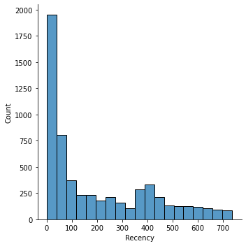

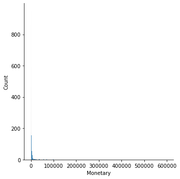

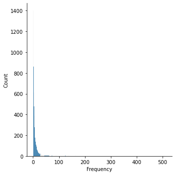

```python
sns.displot(rfm["Recency"])
sns.displot(rfm["Monetary"])
sns.displot(rfm["Frequency"])
```

As the most values of Monetary and Frequency are in [0,10000] and [0,100] respectively. Plot them again.

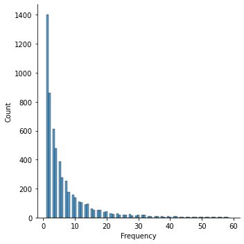

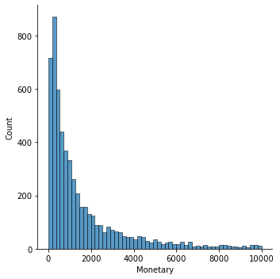

```python
sns.displot(rfm[rfm["Frequency"]<60]["Frequency"])
sns.displot(rfm[rfm["Monetary"]<10000]["Monetary"])
```

Scale the data to [0,1] use MinMaxScaler()

```python
scaler = MinMaxScaler( (0,1) )
rfm_scaled = pd.DataFrame(scaler.fit_transform(rfm[["Recency", "Monetary", "Frequency"]]), columns=["Recency", "Monetary", "Frequency"])
```

Apply Elbow Algorithm

```python
sum_distance_list = []
for i in range(1,11):
    kmeans = KMeans(n_clusters=i, init="random", n_init=10)
    kmeans_fit = kmeans.fit(rfm_scaled)
    sum_distance_list.append(kmeans_fit.inertia_)
```

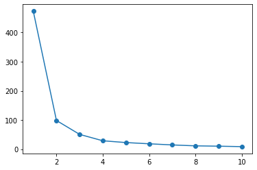

```python
plt.plot(range(1,11), sum_distance_list, "o-")
plt.show()
```

```python
kmeans = KMeans(n_clusters=4, init="random", n_init=10)
kmeans_fit = kmeans.fit(rfm_scaled)
kmeans_cluster = kmeans.predict(rfm_scaled)
```

```python
rfm["Cluster"] = kmeans_cluster
```

```python
rfm
```

|  | Customer ID | Recency | Monetary | Frequency | Recency Score | Frequency Score | Monetary Score | RFM Score | Cluster |
| --- | --- | --- | --- | --- | --- | --- | --- | --- | --- |
| 0 | 12347.0 | 2 | 5633.32 | 8 | 12 | 0 | 9 | 21 | 2 |
| 1 | 12348.0 | 75 | 2019.40 | 5 | 7 | 0 | 7 | 14 | 2 |
| 2 | 12349.0 | 18 | 4404.54 | 5 | 10 | 0 | 8 | 18 | 2 |
| 3 | 12350.0 | 310 | 334.40 | 1 | 4 | 0 | 3 | 7 | 0 |
| 4 | 12352.0 | 36 | 1889.21 | 13 | 9 | 1 | 7 | 17 | 2 |
| ... | ... | ... | ... | ... | ... | ... | ... | ... | ... |
| 5843 | 18283.0 | 3 | 2736.65 | 22 | 12 | 2 | 8 | 22 | 2 |
| 5844 | 18284.0 | 429 | 436.68 | 2 | 3 | 0 | 3 | 6 | 0 |
| 5845 | 18285.0 | 660 | 427.00 | 1 | 1 | 0 | 3 | 4 | 1 |
| 5846 | 18286.0 | 476 | 1188.43 | 3 | 2 | 0 | 6 | 8 | 0 |
| 5847 | 18287.0 | 42 | 4177.89 | 8 | 8 | 0 | 8 | 16 | 2 |

5848 rows × 9 columns

## **Analysis**

```python
rfm.groupby("Cluster").mean()
```

| Cluster | Customer ID | Recency | Monetary | Frequency | Recency Score | Frequency Score | Monetary Score | RFM Score |
| --- | --- | --- | --- | --- | --- | --- | --- | --- |
| 0 | 15326.697842 | 408.435252 | 862.869713 | 3.086331 | 2.939748 | 0.047662 | 3.803957 | 6.791367 |
| 1 | 15438.185484 | 619.067742 | 480.197229 | 1.761290 | 1.217742 | 0.006452 | 2.540323 | 3.764516 |
| 2 | 15281.846129 | 36.104061 | 4486.653077 | 11.273477 | 9.271256 | 0.738579 | 6.071066 | 16.080901 |
| 3 | 15358.975104 | 207.986515 | 1385.739839 | 4.779046 | 5.050830 | 0.145228 | 4.458506 | 9.654564 |

K=4 is used for clustering, so there are 4 groups. Above is the mean value depend on different groups. From the perspective of enterprises, people who buy recently, spend a large amount of money and have a high frequency are loyal customers. On the contrary, they can be regarded as a tourist. Different strategies can be formulated for different groups of people.

Group 0: The average recent purchase date of this group of customers is more than 400 days, with medium frequency and cost. These customers may have come to shop sometimes before, but they are not shopping now for some reason. This group should be regarded as losing customers.

Group 1: This group of customers did not shop for the longest time, with the lowest frequency and cost. These customers should just happen to browse through the goods and buy them. This group of customers should be regarded as tourists.

Group 2: This group of customers buy recently and frequently, and the price is large. This group should be regarded as loyal customers.

```python
rfm["Cluster"].value_counts()
```

```
2    3152
0    1112
3     964
1     620
Name: Cluster, dtype: int64
```

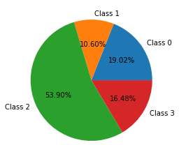

```python
plt.pie(x=[rfm["Cluster"].value_counts()[0], rfm["Cluster"].value_counts()[1], rfm["Cluster"].value_counts()[2], rfm["Cluster"].value_counts()[3]], autopct="%0.2f%%", labels=["Class 0","Class 1","Class 2","Class 3"])
plt.pie
plt.show()
```

From pie chart, group 2, that is the loyal customers account for the highest proportion. These customers are the most important. When resources is limited, they should be served first.

Group 0 and group 3 ranked second and third respectively. Enterprises can use some strategies (such as discount) to turn potential loyal customers into loyal customers and retrieve some lost customers. The number of these customers is still large.

Finally, group 1, although these are tourists, enterprises can regularly publish advertisements and promotions to ensure that customers will not be lost.

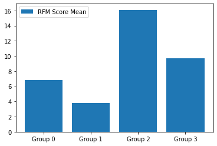

```python
group0_RFMScore = rfm.groupby("Cluster").mean()["RFM Score"][0]
group1_RFMScore = rfm.groupby("Cluster").mean()["RFM Score"][1]
group2_RFMScore = rfm.groupby("Cluster").mean()["RFM Score"][2]
group3_RFMScore = rfm.groupby("Cluster").mean()["RFM Score"][3]

plt.bar(x=["Group 0", "Group 1", "Group 2", "Group 3"], height=[group0_RFMScore, group1_RFMScore, group2_RFMScore, group3_RFMScore], label="RFM Score Mean")
plt.legend()
plt.show()
```

It should be noted that although the number of people in group 0 is more than that in group 3, but the RFM score higher than group 0. Therefore, enterprises should focus on the group 3 more than group 0.

# Question 2: Itemset Rule Mining (4 marks)

For this question, we will be using a [real-world dataset](https://archive.ics.uci.edu/ml/datasets/Congressional+Voting+Records) which gives the votes of 435 U.S. congressmen on 16 key issues gathered in the mid-1980s, and also includes their party affiliation as a binary attribute. This is a purely nominal dataset with some missing values (corresponding to abstentions). It is normally treated as a classification problem, the task being to predict party affiliation based on voting patterns. However, association-rule mining can also be applied to this data to seek interesting associations.

We will be using [Weka](https://www.cs.waikato.ac.nz/ml/weka/), both for its utility for itemset rule mining, and to use a different approach for exploring data. You should have some experience using Weka from the first (non-assessed) week.

You may need to take screenshots of Weka and include them in your answer below, or copy & paste the relevant rules. Please ensure that your answer and rules are clearly legible.

## Q2.1 (3 marks)

In Weka, run `Apriori` on this dataset using default settings. Comment on any patterns you see in the rules that are generated. Also discuss their support, confidence, and lift, demonstrating that you understand how they are calculated, their role, and how to interpret these values.

## Q2.1 Answer

## Preprocess

As original files are .name and .data types. I first convert house-votes-84.names to house-votes-84.csv file. Meanwhile, add the attribute name in the house-vows-84.names file to the CSV filefile.

```python
import pandas as pd

labels = [
    "Class Name",
    "handicapped-infants",
    "water-project-cost-sharing",
    "adoption-of-the-budget-resolution",
    "physician-fee-freeze",
    "el-salvador-aid",
    "religious-groups-in-schools",
    "anti-satellite-test-ban",
    "aid-to-nicaraguan-contras",
    "mx-missile",
    "immigration",
    "synfuels-corporation-cutback",
    "education-spending",
    "superfund-right-to-sue",
    "crime",
    "duty-free-exports",
    "export-administration-act-south-africa"
]
data = pd.read_csv("voting-records/house-votes-84.data", names=labels)

data
```

|  | Class Name | handicapped-infants | water-project-cost-sharing | adoption-of-the-budget-resolution | physician-fee-freeze | el-salvador-aid | religious-groups-in-schools | anti-satellite-test-ban | aid-to-nicaraguan-contras | mx-missile | immigration | synfuels-corporation-cutback | education-spending | superfund-right-to-sue | crime | duty-free-exports | export-administration-act-south-africa |
| --- | --- | --- | --- | --- | --- | --- | --- | --- | --- | --- | --- | --- | --- | --- | --- | --- | --- |
| 0 | republican | n | y | n | y | y | y | n | n | n | y | ? | y | y | y | n | y |
| 1 | republican | n | y | n | y | y | y | n | n | n | n | n | y | y | y | n | ? |
| 2 | democrat | ? | y | y | ? | y | y | n | n | n | n | y | n | y | y | n | n |
| 3 | democrat | n | y | y | n | ? | y | n | n | n | n | y | n | y | n | n | y |
| 4 | democrat | y | y | y | n | y | y | n | n | n | n | y | ? | y | y | y | y |
| ... | ... | ... | ... | ... | ... | ... | ... | ... | ... | ... | ... | ... | ... | ... | ... | ... | ... |
| 430 | republican | n | n | y | y | y | y | n | n | y | y | n | y | y | y | n | y |
| 431 | democrat | n | n | y | n | n | n | y | y | y | y | n | n | n | n | n | y |
| 432 | republican | n | ? | n | y | y | y | n | n | n | n | y | y | y | y | n | y |
| 433 | republican | n | n | n | y | y | y | ? | ? | ? | ? | n | y | y | y | n | y |
| 434 | republican | n | y | n | y | y | y | n | n | n | y | n | y | y | y | ? | n |

435 rows × 17 columns

```python
data.to_csv("voting-records/house-votes-84.csv", index=False)
```

## Steps

First open Weka and click Explorer

[figure not shown]

Click [Open File] option, open the house-votes-84.csv file generated above

[figure not shown]

Now we can check all attributes in [Attribute] box, and check the values of selected attribute in [Selected attribute] box

[figure not shown]

This is the statistics of all attributes when Class Name is selected, then click visualize all.

For example, there are 236 negative votes in handicapped-infants, more than half of them are Republican, 187 positive votes in handicapped-infants, most of them are democracy.

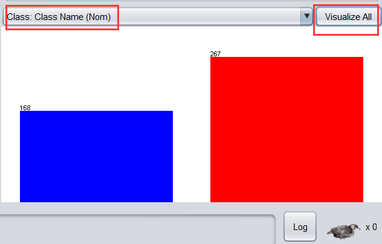

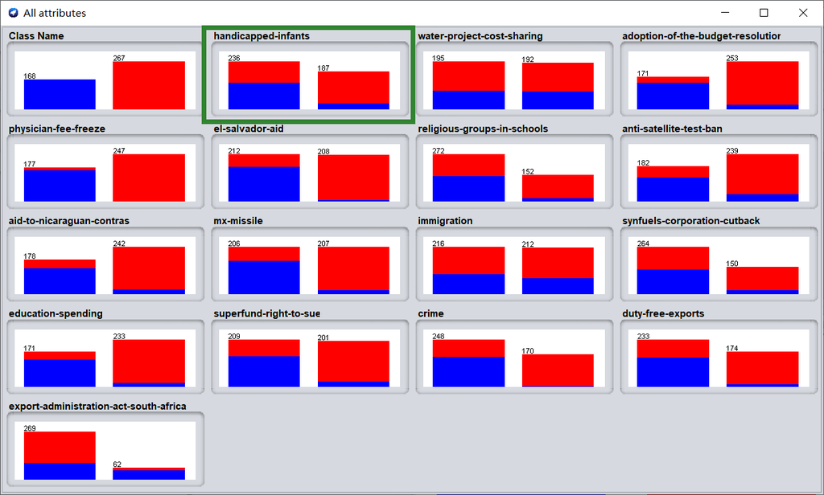

For Apriori, choose [Associate], click [Choose] button to choose Apriori algorithm

[figure not shown]

The settings are default.

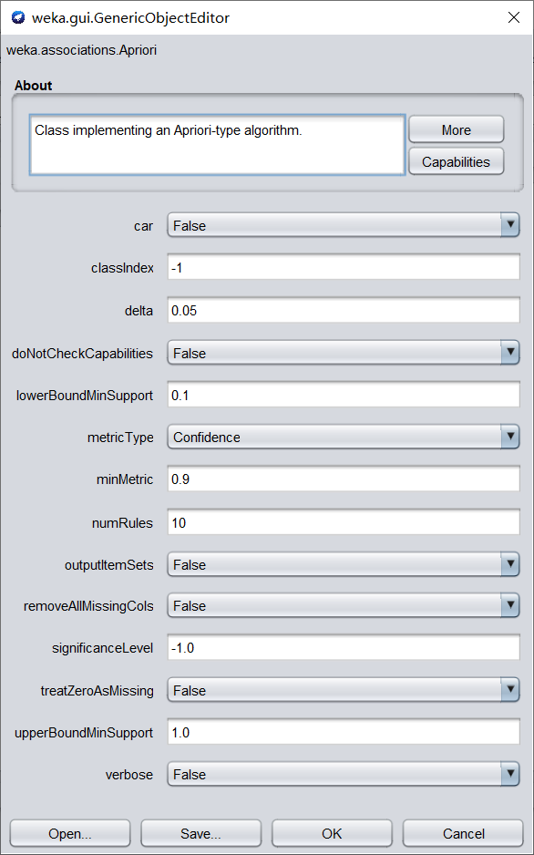

Click start to perform Apriori algorithm

[figure not shown]

## Result

The result is

[figure not shown]

And the 10 best rules found by Apriori algorithms are:

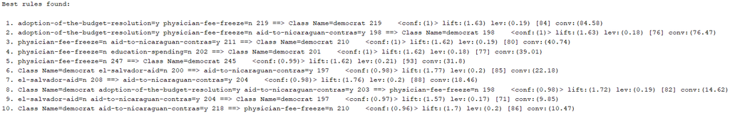

Best rules found:

1. adoption-of-the-budget-resolution=y physician-fee-freeze=n 219 ==> Class Name=democrat 219 \conf:(1) lift:(1.63) lev:(0.19) [84] conv:(84.58)
2. adoption-of-the-budget-resolution=y physician-fee-freeze=n aid-to-nicaraguan-contras=y 198 ==> Class Name=democrat 198 \conf:(1) lift:(1.63) lev:(0.18) [76] conv:(76.47)
3. physician-fee-freeze=n aid-to-nicaraguan-contras=y 211 ==> Class Name=democrat 210 \conf:(1) lift:(1.62) lev:(0.19) [80] conv:(40.74)
4. physician-fee-freeze=n education-spending=n 202 ==> Class Name=democrat 201 \conf:(1) lift:(1.62) lev:(0.18) [77] conv:(39.01)
5. physician-fee-freeze=n 247 ==> Class Name=democrat 245 \conf:(0.99) lift:(1.62) lev:(0.21) [93] conv:(31.8)
6. Class Name=democrat el-salvador-aid=n 200 ==> aid-to-nicaraguan-contras=y 197 \conf:(0.98) lift:(1.77) lev:(0.2) [85] conv:(22.18)
7. el-salvador-aid=n 208 ==> aid-to-nicaraguan-contras=y 204 \conf:(0.98) lift:(1.76) lev:(0.2) [88] conv:(18.46)
8. Class Name=democrat adoption-of-the-budget-resolution=y aid-to-nicaraguan-contras=y 203 ==> physician-fee-freeze=n 198 \conf:(0.98) lift:(1.72) lev:(0.19) [82] conv:(14.62)
9. el-salvador-aid=n aid-to-nicaraguan-contras=y 204 ==> Class Name=democrat 197 \conf:(0.97) lift:(1.57) lev:(0.17) [71] conv:(9.85)
   1. Class Name=democrat aid-to-nicaraguan-contras=y 218 ==> physician-fee-freeze=n 210 \conf:(0.96) lift:(1.7) lev:(0.2) [86] conv:(10.47)

## Analysis

Term Explaination

Support: The proportion of itemsets that appear in the database. It can be calculated by the number of occurrences of the itemset in the database divided by the number of total itemsets in the database.

Confidence: Confidence(A->B) is probability of occurrence of B on the premise that A has already been given. It can be calculated by the Support(A∪B) divided by Support(A)

Lift: Lift(A->B) is the increase in the ratio of B occur when A occur. If value is 1, then no association between A and B. If value is greater than 1, it implies B likely to occur when A occurs. If value is less than 1, it means B is unlikely to occur when x occurs. It can be calculated by Confidence(A->B) divided by Support(B)

For this dataset, The frequent itemsets L(1) contains 20 instances, the itemsets L(2) contains 17 instances, the frequent itemsets L(3) contain 6 instances, and the frequent itemsets L(4) contains only 1 instance.

From the first rule, it can be seen that Democrat supports adoption-of-the-budget-resolution and opposes the physician-fee-freeze. The lift value is 1.63 means that a person who support adoption-of-the-budget-resolution and opposes the physician-fee-freeze is more likely to be a Democrat. Combined with the confidence value of 1, then it is certain that the person must be a Democrat. There are 219 data support this rule. It is strongly associated with Democrat in support of adoption-of-the-budget-resolution and not support of physician-fee-freeze.

This analysis also applies to rule 2, 3, 4, 5, 9.

It should be noted that the confidence of 5 and 9 are 0.99 and 0.97, and the lift is 1.62 and 1.57, respectively. It shows that most of those who oppose physician-fee-freeze are likely a Democrats, most of those who oppose el-salvador-aid and most of those who support aid-to-nicaraguan-contras are likely a Democrats, not 100%.

From the sisth rule, Democrat who opposes el-salvador-aid is likely to support aid-to-nicaraguan-contras. It is indicated by lift = 1.77 and conf = 0.98 that if a Democrat opposes el-salvador-aid, it is very likely to support aid-to-nicaraguan-contras.

This analysis also applies to rule 7,8,10

Overall, it can be infered that democrat trends to opposes physician-fee-freeze, education-spending and el-salvador-aid, more likely to support adoption-of-the-budget-resolution and aid-to-nicaraguan-contras.

## Q2.2 (1 mark)

It is interesting to see that none of the rules in the default output involve `class = republican`. Why do you think that is?

## Q2.2 Answer

As can be seen from the figure below, the number of votes for republican and democrat differs approximately 100 votes. Then for each attribute, if republican is biased towards support, then democrat must be biased towards opposition (and vice versa, like physician-fee-freeze arrtibute in figure). However, there is more democrat, so the dominance is stronger.

The support value of the apriori algorithm is to analyze each item set. If there are few itemsets, there will be fewer frequent sets generated subsequently. The itemsets of democrate appear frequently, so there are many subsequent sets. So the output involves more `class = democrat`, resulting in less `class = Republican`.

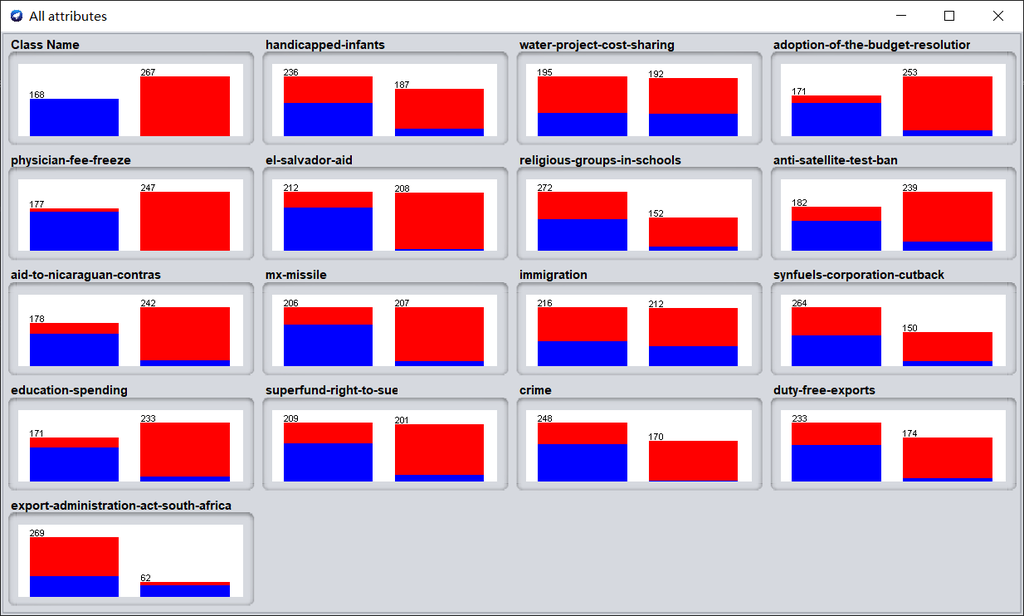

Reference List for Question 2

Ng, A. (2016). *Association Rules and the Apriori Algorithm: A Tutorial.* [online] KDnuggets. Available at: https://www.kdnuggets.com/2016/04/association-rules-apriori-algorithm-tutorial.html/2 [Accessed 24 Oct. 2021].

Hahsler, M. (2004). *Commonly Used Interest Measures for Association Rules.* [online] michael.hahsler.net. Available at: https://michael.hahsler.net/research/recommender/associationrules.html [Accessed 24 Oct. 2021].